# Branding and Automating Your Work with R Markdown

Sorenson Impact Center

## Rmarkdown Refresher

- Use multiple languages including R, Python, and SQL.
- Output formats include HTML, PDF, MS Word, Beamer, HTML5 slides, Tufte-style handouts, books, dashboards, shiny applications, scientific articles, websites, and more.

[figure not shown]

## The Precursor to Notebooks

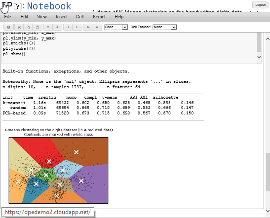

## Problems Rmarkdown Solves

- Combines code and output
- Facilitated by RStudio (but no IDE required)
- Version control!!!
- http://danielphadley.com/Jupyter-to-Rmarkdown/

## Branding a Word Doc

## Example

[figure not shown]

## Example

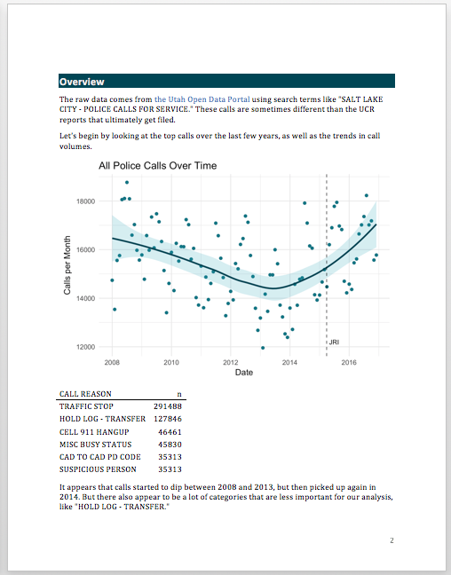

## Example

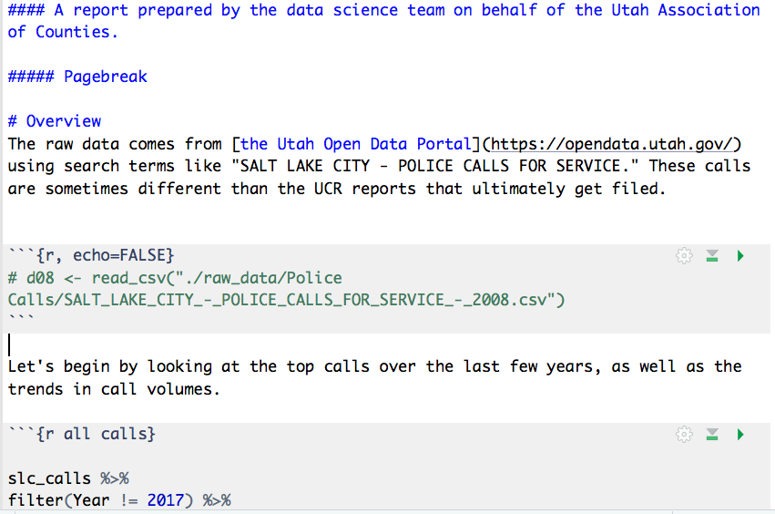

## Useful Example: Page Breaks

- Set up a docx style reference
- Modify style ‘Heading 5’ :
- Set the font color to ‘white’ (rather than ‘Automatic’).
- Select the smallest font size (8 rather than 11).
- Select ‘Page break before’ in the ‘Line and Page Breaks’ tab.

https://datascienceplus.com/r-markdown-how-to-insert-page-breaks-in-a-ms-word-document/

## Example

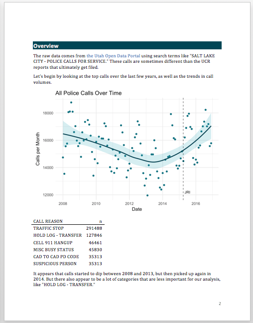

```r
##### Pagebreak

# Overview
The raw data comes from ...
```

## Branding Images

[figure not shown]

## Branding Images with Magick

[figure not shown]

## Branding Images with Magick

[figure not shown]

## Branding Images with Magick

```r
# Our function in Pseudocode

si_ggsave <- function(){

  ggsave(lastplot)

  if(add_logo){

    logo <- image_read("~/ourlogo.png") %>%
      #make the width of the logo match the width of the plot
      image_crop(paste0(pwidth, "x0+0+0"))

    # The final version is stacked on top of the sorenson logo
    final_plot <- image_append(c(lastplot, logo), stack = TRUE)
    # And then we overwrite the standard ggsave call
    image_write(final_plot, filename)
  }
}
```

## Packaging Your Brand

## Customizations Add Up

Setup chunk: over **100** lines

- Load libraries
- Set knitr/rmarkdown options
- Set directories
- Define SI color names
- Customize ggplot themes and geoms
- Define custom functions

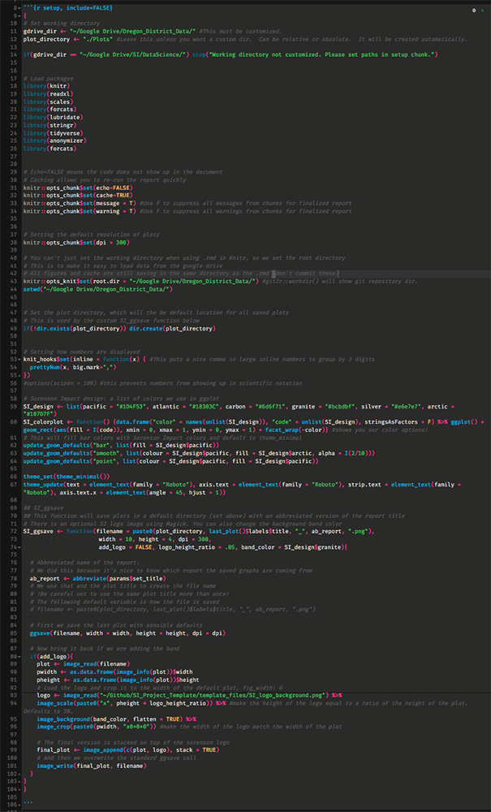

## Goals

Part 1

- Reduce setup chunk
- Corral custom functions

Part 2

- Effortless creation of new RMarkdown documents
- Single-source templates that upgrade easily
- Future proof / time-locked

## Reduce Setup Chunk

Move all settings into broad "apply_settings()" type functions

```r
si_ggplot_theme_apply <- function() {

  ggplot2::update_geom_defaults("bar", list(fill = si_design$pacific))
  ggplot2::update_geom_defaults("smooth", list(
    colour = si_design$pacific,
    fill = si_design$arctic, alpha = I(2/10)))
  ggplot2::update_geom_defaults("point", list(
    colour = si_design$pacific,
    fill = si_design$pacific))
  ggplot2::update_geom_defaults("col", list(fill = si_design$pacific))

  ggplot2::theme_set(ggplot2::theme_minimal())
}
```

## Easy Creation of Rmarkdown Template

- **inst/** dir in package can hold anything
- Contents are copied to local R/library/package dir on package install/update
- Location of local files is queryable with base R function

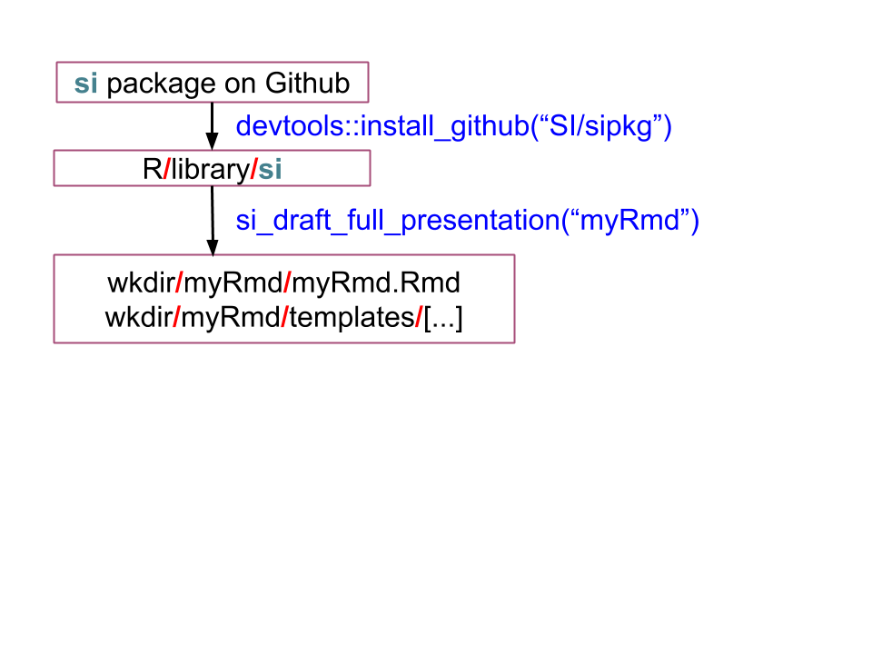

## Using a Package for Template Storage

- **inst/** dir in package can hold anything
- Contents are copied to local R/library/package dir on package install/update
- Location of local files is queryable with base R function

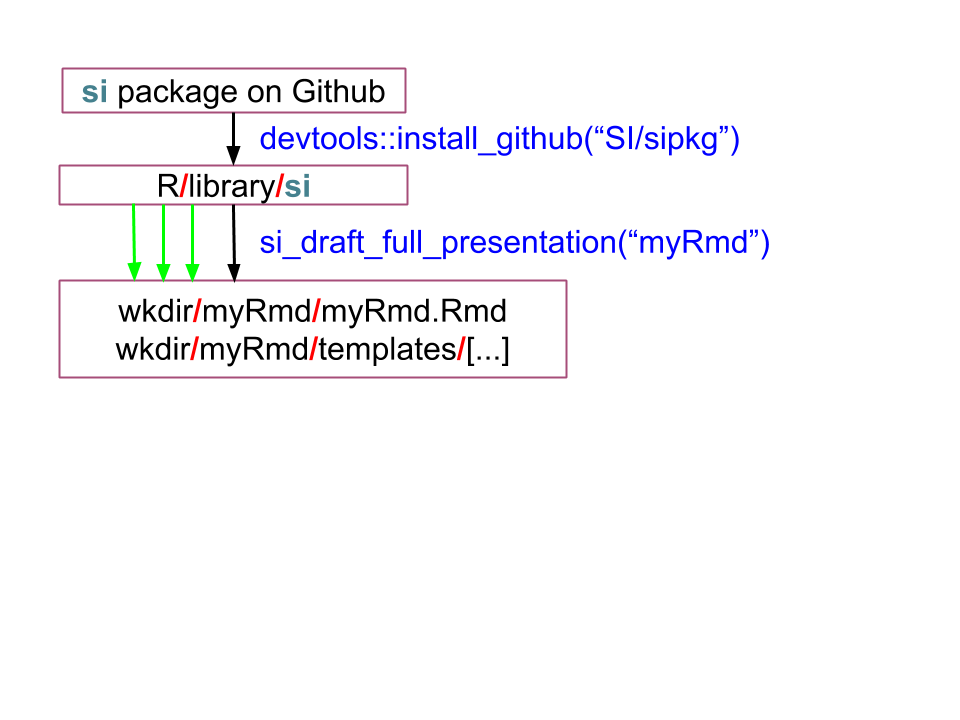

## Draft Function

```r
# Our draft function in Pseudocode
si_draft_full_report <- function(file) {

  if(empty(dirname(file))) { #Create dir if not provided
    file <- file.path(default_dir, file)
  }

  if(tools::file_ext(file) != "Rmd") { #Fix the capitalization of Rmd
    message("Daniel you messed up the capitalization again. Setting extension to .Rmd")
    file <- paste0(tools::file_path_sans_ext(file), ".Rmd")
  }
  rmarkdown::draft(file = file,
                   template = "si_full_report",
                   package = "sorensonimpact",
                   edit = F)

  file.edit(file) #Open immediately in Rstudio editor
}
```

## Draft Function in Action

[video not shown]

## Finishing Touches

One final piece…

## Finishing Touches

One final piece…

[figure not shown]

## Automating Your Work

## An Old Method: Knitting to HTML

```r
<!DOCTYPE html>

  <script>
  $(function() {
    $('#container').highcharts({
      xAxis: {
        categories: [<!--rinline I(shQuote(dates)) -->]
      },
      series: [{
        name: 'Tokyo',
        data: [<!--rinline I(Tokyo) -->]
      }, {
        name: 'London',
        data: [<!--rinline I(London) -->]
      }]
    });
  });
</script>
```

## Automating is Easy Now

```r
for (county in unique(utah$County)) {
  try(render('./county_report.Rmd',
             output_file = paste(county, "County Report.docx"),
             output_dir = "./County_Reports/"))
}
```

## A New Method

Create a script that

- loads data (e.g, from Google Sheets)
- renders a report from an .Rmd
- saves the output (e.g., an HTML dashboard)
- emails the result

Automate the Script

- Windows task manager OR
- Cron (e.g., on a Raspberry Pi)

https://www.r-bloggers.com/scheduling-r-markdown-reports-via-email/